# QC of RST efficiency trial data

This document performs QC on efficiency data focused on three things:

1. Potential interuptions in efficiency trials
2. Using the “include_in_analysis” field
3. Potential differences in day and night releases

# Potential interruptions in efficiency trials

The goal is to identify efficiency trials that were incomplete due to the trap being non-operational after fish were released. This might happen when flows are very high. We evaluate this in two ways: (1) Count the number of consecutive days the trap was operational after release using the RST trap and catch data (2) Pull flow data for the 4 days after release and identify any where flow is high (defined as above 10,000 cfs though this may be lower in some locations)

**Approach 1**

- 338 release trials were flagged as potentially being non-operational for 1-4 days after release.
- 77 release trials were flagged as potentially being non-operational 1 day after release

*Table of potential trials that were not operational 1 day after release*

| release_id | stream | site |
| --- | --- | --- |
| 7 | feather river | eye riffle |
| 36 | feather river | live oak |
| 37 | feather river | live oak |
| 40 | feather river | eye riffle |
| 55 | feather river | herringer riffle |
| 44 | feather river | eye riffle |
| 77 | feather river | herringer riffle |
| 73 | feather river | eye riffle |
| 84 | feather river | herringer riffle |
| 74 | feather river | eye riffle |
| 87 | feather river | eye riffle |
| 89 | feather river | eye riffle |
| 110 | feather river | herringer riffle |
| 111 | feather river | herringer riffle |
| 112 | feather river | herringer riffle |
| 124 | feather river | herringer riffle |
| 126 | feather river | eye riffle |
| 141 | feather river | herringer riffle |
| 142 | feather river | herringer riffle |
| 145 | feather river | herringer riffle |
| 130 | feather river | eye riffle |
| 149 | feather river | herringer riffle |
| 134 | feather river | eye riffle |
| 564 | feather river | eye riffle |
| 573 | feather river | eye riffle |
| 574 | feather river | eye riffle |
| 135 | feather river | eye riffle |
| 565 | feather river | eye riffle |
| 155 | feather river | herringer riffle |
| 181 | feather river | herringer riffle |
| 186 | feather river | steep riffle |
| 187 | feather river | steep riffle |
| 190 | feather river | steep riffle |
| 191 | feather river | steep riffle |
| 243 | feather river | herringer riffle |
| 235 | feather river | steep riffle |
| 521 | feather river | sunset pumps |
| 558 | feather river | steep riffle |
| 951 | feather river | sunset pumps |
| 958 | feather river | sunset pumps |
| 952 | feather river | sunset pumps |
| 739 | feather river | herringer riffle |
| 792 | feather river | herringer riffle |
| 914 | feather river | eye riffle |
| BAT340 | battle creek | ubc |
| BAT350 | battle creek | ubc |
| 262 | sacramento river | knights landing |
| 268 | sacramento river | knights landing |
| 269 | sacramento river | knights landing |
| 579 | sacramento river | knights landing |
| 580 | sacramento river | knights landing |
| 286 | sacramento river | tisdale |
| 292 | sacramento river | tisdale |
| 293 | sacramento river | tisdale |
| 294 | sacramento river | tisdale |
| 295 | sacramento river | tisdale |
| 296 | sacramento river | tisdale |
| 297 | sacramento river | tisdale |
| 298 | sacramento river | tisdale |
| KNL26 | sacramento river | knights landing |
| KNL27 | sacramento river | knights landing |
| KNL28 | sacramento river | knights landing |
| KNL29 | sacramento river | knights landing |
| KNL30 | sacramento river | knights landing |
| KNL52 | sacramento river | knights landing |
| KNL65 | sacramento river | knights landing |
| KNL78 | sacramento river | knights landing |
| KNL81 | sacramento river | knights landing |
| KNL82 | sacramento river | knights landing |
| KNL83 | sacramento river | knights landing |
| KNL84 | sacramento river | knights landing |
| KNL85 | sacramento river | knights landing |
| mill202202 | mill creek | mill creek |
| mill202204 | mill creek | mill creek |
| mill202205 | mill creek | mill creek |
| mill202206 | mill creek | mill creek |
| mill202207 | mill creek | mill creek |

The majority of these are coming from the Feather River and Sacramento River

*Table of potential trials that were not operational 1 day after release summarized by stream*

| stream | n |
| --- | --- |
| battle creek | 2 |
| feather river | 44 |
| mill creek | 5 |
| sacramento river | 26 |

**Approach 2**

192 release trials were flagged as flow being potentially too high to operate the traps.

| release_id | stream | site |
| --- | --- | --- |
| 4 | feather river | live oak |
| 119 | feather river | herringer riffle |
| 175 | feather river | herringer riffle |
| 176 | feather river | herringer riffle |
| 179 | feather river | herringer riffle |
| 180 | feather river | herringer riffle |
| 181 | feather river | herringer riffle |
| 951 | feather river | sunset pumps |
| 958 | feather river | sunset pumps |
| 952 | feather river | sunset pumps |
| 685 | feather river | herringer riffle |
| 682 | feather river | gateway riffle |
| 681 | feather river | gateway riffle |
| 683 | feather river | gateway riffle |
| 684 | feather river | gateway riffle |
| 742 | feather river | herringer riffle |
| 743 | feather river | herringer riffle |
| 925 | feather river | herringer riffle |
| 930 | feather river | herringer riffle |
| 947 | feather river | herringer riffle |
| 948 | feather river | herringer riffle |
| 955 | feather river | herringer riffle |
| 956 | feather river | herringer riffle |
| 957 | feather river | herringer riffle |
| 265 | sacramento river | knights landing |
| 1 | sacramento river | knights landing |
| 256 | sacramento river | knights landing |
| 262 | sacramento river | knights landing |
| 263 | sacramento river | knights landing |
| 266 | sacramento river | knights landing |

[output cut: 162 more lines]

The majority of these were on the Sacramento River.

| stream | n |
| --- | --- |
| feather river | 24 |
| sacramento river | 168 |

There were 51 release trials that were flagged for both issues with missing trap data (1-4 days after release) and having high flows. When using the criteria of non-operational 1-day after release, there were 20 flagged trials.

These are the highest priority for QC and potential removal. These occur in the Feather River and Sacramento River.

*Table of high priority flags using the 1-4 day criteria*

| release_id | stream | site |
| --- | --- | --- |
| 176 | feather river | herringer riffle |
| 179 | feather river | herringer riffle |
| 180 | feather river | herringer riffle |
| 181 | feather river | herringer riffle |
| 951 | feather river | sunset pumps |
| 958 | feather river | sunset pumps |
| 952 | feather river | sunset pumps |
| 685 | feather river | herringer riffle |
| 683 | feather river | gateway riffle |
| 684 | feather river | gateway riffle |
| 947 | feather river | herringer riffle |
| 262 | sacramento river | knights landing |
| 269 | sacramento river | knights landing |
| 561 | sacramento river | knights landing |
| 562 | sacramento river | knights landing |
| 575 | sacramento river | knights landing |
| 577 | sacramento river | knights landing |
| 579 | sacramento river | knights landing |
| 580 | sacramento river | knights landing |
| 608 | sacramento river | knights landing |
| 574 | sacramento river | knights landing |
| 275 | sacramento river | tisdale |
| 293 | sacramento river | tisdale |
| 294 | sacramento river | tisdale |
| 295 | sacramento river | tisdale |
| 296 | sacramento river | tisdale |
| 297 | sacramento river | tisdale |
| 306 | sacramento river | tisdale |
| 320 | sacramento river | tisdale |
| 321 | sacramento river | tisdale |
| 324 | sacramento river | tisdale |
| 325 | sacramento river | tisdale |
| KNL1 | sacramento river | knights landing |
| KNL23 | sacramento river | knights landing |
| KNL24 | sacramento river | knights landing |
| KNL25 | sacramento river | knights landing |
| KNL26 | sacramento river | knights landing |
| KNL27 | sacramento river | knights landing |
| KNL28 | sacramento river | knights landing |
| KNL29 | sacramento river | knights landing |
| KNL30 | sacramento river | knights landing |
| KNL31 | sacramento river | knights landing |
| KNL65 | sacramento river | knights landing |
| KNL71 | sacramento river | knights landing |
| KNL72 | sacramento river | knights landing |
| KNL73 | sacramento river | knights landing |
| KNL76 | sacramento river | knights landing |
| KNL77 | sacramento river | knights landing |
| KNL78 | sacramento river | knights landing |
| KNL79 | sacramento river | knights landing |
| KNL80 | sacramento river | knights landing |

## Compare efficiency with and without flagged trials

High priority flagged trials = non-operational 1-4 days after release and high flows

When removing the high priority release trials we see some small differences in average efficiency, mostly for Knights Landing.

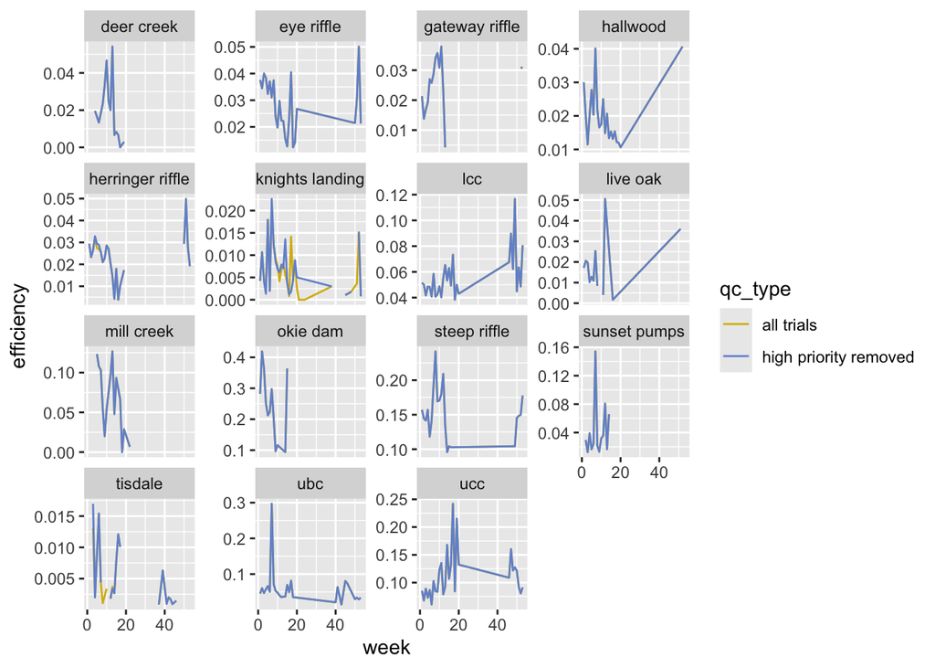

# Use the “include_in_analysis” field

There is a “include_in_analysis” column available for the `release` table. Only Feather River uses this and has marked 74 trials as not to be used in analysis. There is one trial for Knights Landing.

It is unclear why these trials are not used in analysis. We are testing if removing these has an impact on efficiency.

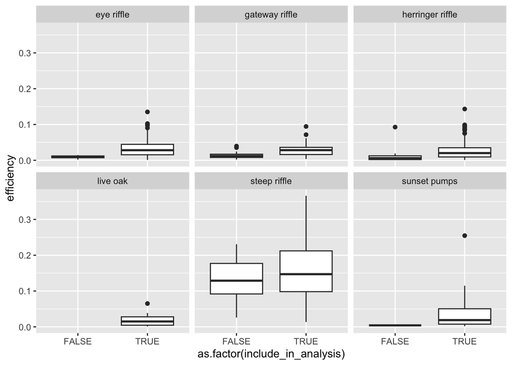

# Day and night release exploration

We use our original standard format datasets that include time of release. If this ends up being important we can figure out how to get these added to the `release` table.

There are very few releases done at night (200 out of 2,098).

Most night releases occur at Battle or Clear Creek. There is a small difference in efficiency at Butte Creek between night and day releases.

```
# A tibble: 8 × 2
  site                        n
  <chr>                   <int>
1 gateway riffle             12
2 herringer riffle           10
3 knights landing             1
4 lcc                        50
5 okie dam                    9
6 red bluff diversion dam     4
7 ubc                        66
8 ucc                        48
```

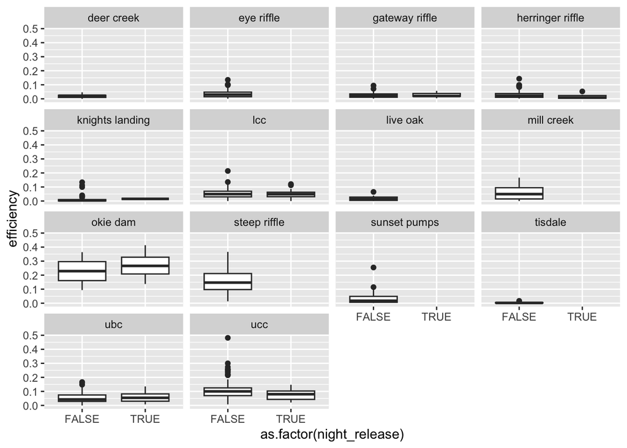